# Create Validation Data from CDL & NEI 2011

Kenneth Qin

June 21, 2017

## Background

This is a part of the EDF Sustainable Agriculture program’s pilot project for the remote sensing of excess nitrogen on cultivated lands.

The main barrier to successfully deploying a satellite-based remote sensing system for targeted fertilizer conservation programs is the lack of sufficient ground-truthed field-scale fertilizer application data. In theory, if we could receive annual reports of yield, crop type, and nitrogen (N) fertilizer application rate from each field in the U.S., we could develop a crude N-balance prediction system that operates at the field-scale. However, this data is elusive in part because of the legitimate concern for farmers’ privacy rights. A recent study from Iowa State University reported that “30% of farmers agreed that government use of remote sensing and other tools to identify issues on private land is an invasion of privacy” (Arbuckle, 2013).

In this pilot project, **we do not attempt to predict field-scale attributes using satellite remote sensing**. Instead, we attempt to predict the mean and heterogeneity of **N-balance at the county scale**.

County-scale information on total N fertilizer usage was made available in the EPA’s 2011 National Emissions Inventory (NEI) report. When combined with the Cropland Data Layer’s pixel counts of each land cover type for each county, we can identify those counties where the vast majority (i.e. > 95%) of all cultivated area consists of corn/soybean, and make the assumption that all N fertilizer within the county was applied to corn acreage. Through this process we can arrive at a **mean fertilizer application rate for corn** for a large subset of counties.

County-level yield data can be retrieved from the USDA National Agricultural Statistics Service (NASS) via Quick Stats.

**County-level N-balance for corn** can then be calculated through the following equation:

$$N.balance = N.input - N.output = N.input - Yield * N.removal.rate$$

This simplified N-balance equation is sufficient for our purpose of generating county-level validation data, though we recognize that we are making the following assumptions:

- Corn stover / stubble is not removed from the field.
- The grain has the standard moisture content of 15.5%.
- The grain has a constant N concentration of 1.4%.

*See http://www.ipni.net/article/IPNI-3296 for details on the grain N calculation.*

Once N-balance has been calculated for each county, we will have produced a dataset for use in validating an *a priori* model that converts vegetation indices collected through satellite remote sensing into county-level N-balance predictions.

## Analysis

Define constants, load libraries, and import data.

```r
# Constants

SQ_METER_PER_PIXEL <- 900
SQ_METER_PER_ACRE <- 4046.86
ACRES_PER_SQ_MILE <- 640

# Libraries

library(dplyr)
library(stringr)
library(reshape2)
library(ggplot2)
# Data imports

#setwd("C:/Users/kqin/Documents/Remote Sensing/Remote Sensing of N/Validation Data/CDL")

fips <- read.csv("fips_codes.csv")

CDL2016 <- read.csv("CDL_Cnty_Pixel_2016_30m.csv")

category.names <- read.csv("class_names.csv")
cultivated.codes <- category.names$CODE[which(category.names$CULTIVATED)]
cultivated.codes.str <- str_pad(cultivated.codes, 3, side="left", "0")
cultivated.cats <- paste("Category_", cultivated.codes.str, sep="")
```

Merge county pixel-count data with county FIPS-code data.

```r
fips$Fips <- fips$STATEFP*1000 + fips$COUNTYFP
CDL2016.m <- merge(fips, CDL2016, by="Fips")
```

Convert pixel-counts into sq. miles and acres.

```r
CDL2016.sqm <- CDL2016.m
CDL2016.sqm[1:nrow(CDL2016.sqm),8:ncol(CDL2016.sqm)] <-
  CDL2016.sqm[1:nrow(CDL2016.sqm),8:ncol(CDL2016.sqm)] * SQ_METER_PER_PIXEL

CDL2016.ac <- CDL2016.sqm
CDL2016.ac[1:nrow(CDL2016.ac),8:ncol(CDL2016.ac)] <-
  CDL2016.ac[1:nrow(CDL2016.ac),8:ncol(CDL2016.ac)] / SQ_METER_PER_ACRE
```

Calculate total area and total cultivated area in each county.

```r
CDL2016.ac$Total_ac <- rowSums(select(CDL2016.ac, Category_001:Category_254))
CDL2016.ac$Total_sqmi <- CDL2016.ac$Total_ac/ACRES_PER_SQ_MILE

CDL2016.ac$Total_cult_ac <- rowSums(select(CDL2016.ac, one_of(cultivated.cats)))
```

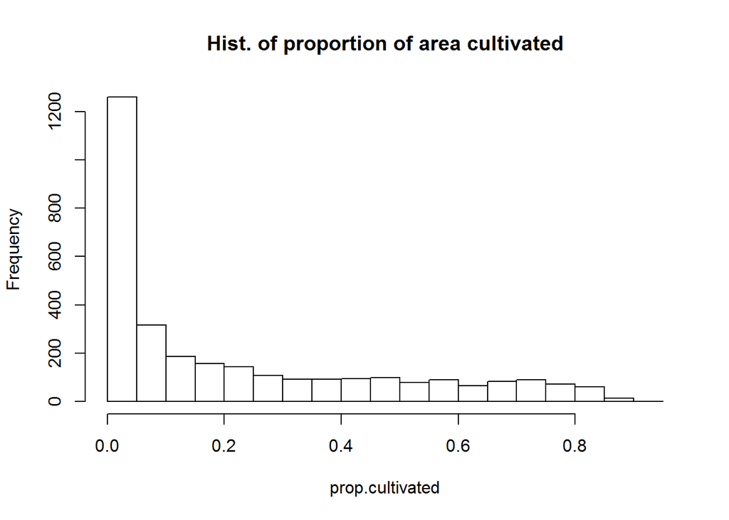

```r
CDL2016.ac$Total_cult_sqmi <- CDL2016.ac$Total_cult_ac/ACRES_PER_SQ_MILE

# Ensure that cultivated area is less than total area
prop.cultivated <- CDL2016.ac$Total_cult_ac / CDL2016.ac$Total_ac
hist(prop.cultivated, main="Hist. of proportion of area cultivated")
```

Calculate proportion of corn+soybean out of total CULTIVATED AREA.

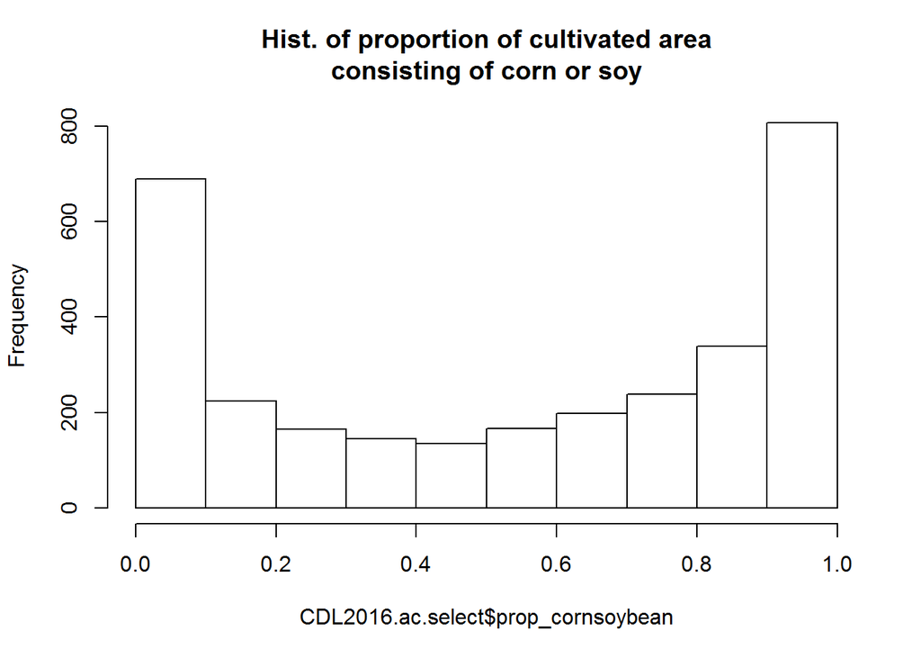

```r
CDL2016.ac.select <- select(CDL2016.ac, -(Category_001:Category_254))

CDL2016.ac.select %>%
  mutate(prop_corn = Corn_all / Total_cult_ac,
         prop_soybean = Soybeans_all / Total_cult_ac,
         prop_cornsoybean = (Corn_all + Soybeans_all) / Total_cult_ac) ->
  CDL2016.ac.select

hist(CDL2016.ac.select$prop_cornsoybean, main="Hist. of proportion of cultivated area\nconsisting of corn or soy")
```

Identify counties with over 95% of cultivated acres consisting of corn or soy.

First, what proportion of counties have over 95% of their cultivated acreage consist of corn or soy?

```r
# Answer: For 95% threshold, 18% of counties (N=568).
#         For 90% threshold, 26% of counties (N=806).
mean(CDL2016.ac.select$prop_cornsoybean > 0.95, na.rm=TRUE)
```

```
## [1] 0.1829308
```

```r
# Record these counties' fips codes
ind.95.cornsoy <- which(CDL2016.ac.select$prop_cornsoybean > 0.95)
cornsoy.counties.fips <- CDL2016.ac.select$Fips[ind.95.cornsoy]
```

Where are these counties?

```r
# Where are these counties?
CDL2016.ac.select[ind.95.cornsoy,] %>%
  group_by(STATE) %>%
  summarise(state_n = n()) %>%
  arrange(desc(state_n)) ->
  CDL.95.statecount
CDL.95.statecount
```

```
## # A tibble: 22 × 2
##     STATE state_n
##    <fctr>   <int>
## 1      IL      97
## 2      IA      76
## 3      KY      70
## 4      MO      70
## 5      IN      66
## 6      TN      49
## 7      NE      34
## 8      MN      19
## 9      OH      17
## 10     MS      16
## # ... with 12 more rows
```

What else do these counties grow?

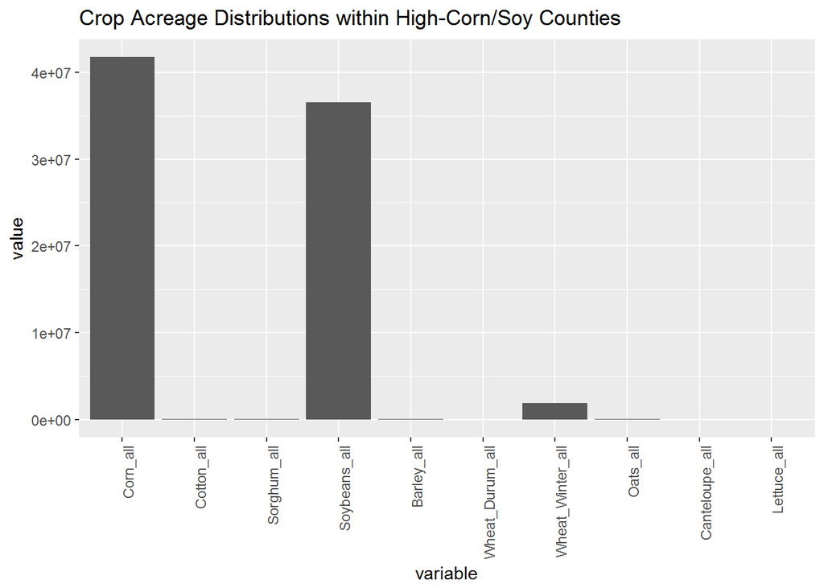

```r
# What are the other crops in these counties?
CDL2016.ac.select[ind.95.cornsoy,] %>%
  select(Corn_all:Lettuce_all) %>%
  summarise_each(funs(sum)) ->
  temp
ggplot(melt(temp), aes(x=variable, y=value)) + geom_bar(stat='identity') +
  theme(axis.text.x = element_text(angle=90, hjust=1)) +
  ggtitle("Crop Acreage Distributions within High-Corn/Soy Counties")
```

Aside from corn and soybean, these counties also grow a substantial amount of winter wheat. Winter wheat removes almost twice as much N as corn, which may bias the corn N-balance downwards, but this bias will probably be balanced out by the remainder of crops taking less N than corn. Besides, these crops only make up to 5% of total acreage in these counties.